# Fintech Enigma Analyse Portefølje

I denne Jupyter Notebook-en utfører vi en analyse av vår investeringsportefølje ved hjelp av Python. Formålet er å evaluere porteføljens ytelse, identifisere risiko- og avkastningskarakteristikker, og optimalisere fordelingen av aktiva for å oppnå de beste resultatene. Analysene er dog ikke brukt eller vektlag mye i henhold til den portøljen vi har nå, men vi ønsker å oppnå dette på sikt. Dette er mest for å vise hvordan man kan bruke python for å visualisere og analsyere en allerede eksisterende aksjeportefølje.

En av de mest relevante teoriene om porteføljeoptimalisering ble utviklet av Harry Markowitz. Hans teori, kjent som moderne porteføljeteori, sier at en investorer kan bygge en portefølje som maksimerer forventet avkastning gitt et forhåndsdefinert risikonivå.

Sentralt i porteføljeteorien er ideen om at man kan diversifisere risikoen ved å kombinere ulike aktiva i en portefølje. Hovedmålet er å oppnå den optimale balansen mellom forventet avkastning og volatilitet.

Porteføljeteorien tar hensyn til at avkastningen på ulike aktiva ikke alltid beveger seg i takt; noen kan øke i verdi mens andre synker. Ved å kombinere aktiva med lav eller negativ korrelasjon, kan en investor redusere den totale porteføljerisikoen.

Arbeidet er en blanding av selvkodet, og hentet litt fra diverse kilder. Der hvor kode/inspirasjon er hentet, er det linket til hvor.

# Generell Info og aksjepriser

Her viser aksjen hvor mye du ville fått tilbake om du hadde invesetert 1kr i den ved start

```
[*********************100%%**********************]  10 of 10 completed
[*********************100%%**********************]  9 of 9 completed
```

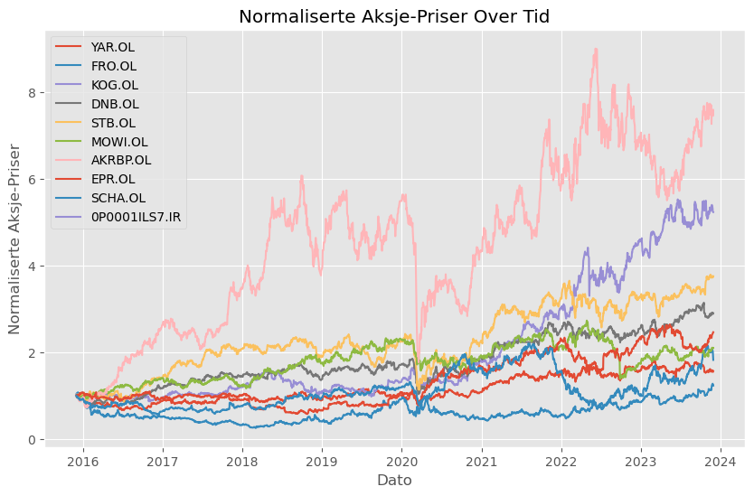

```python
import yfinance as yf
import datetime as dt
import pandas as pd
import matplotlib.pyplot as plt
import seaborn as sns
import numpy as np

plt.style.use('ggplot')


start_t = dt.datetime(2015, 12, 1)
end_t = dt.datetime(2023, 12, 1)

# Tickers
tickers_t = ['YAR.OL', 'FRO.OL', 'KOG.OL', 'DNB.OL', 'STB.OL', "MOWI.OL", "AKRBP.OL", "EPR.OL", "SCHA.OL", "0P0001ILS7.IR"]
tickers_s = ['YAR.OL', 'FRO.OL', 'KOG.OL', 'DNB.OL', 'STB.OL', "MOWI.OL", "AKRBP.OL", "EPR.OL", "SCHA.OL"]
holders = [0.088, 0.096, 0.112, 0.097, 0.096, 0.105, 0.1, 0.097, 0.091, 0.118]
weights = [0.088, 0.096, 0.112, 0.097, 0.096, 0.105, 0.1, 0.097, 0.091]


data = yf.download(tickers_t, start_t, end_t)['Adj Close'].ffill()
data_2 = yf.download(tickers_s, start_t, end_t)['Adj Close'].ffill()


normalized_data = data / data.iloc[0, :]


returns = data_2.pct_change(1).dropna()


colors = plt.cm.viridis(np.linspace(0, 1, len(tickers_t)))

plt.figure(figsize=(10, 6))
for ticker in tickers_t:
    plt.plot(normalized_data.index, normalized_data[ticker], label=ticker)


plt.title('Normaliserte Aksje-Priser Over Tid')
plt.xlabel('Dato')
plt.ylabel('Normaliserte Aksje-Priser')
plt.legend()
plt.grid(True)


plt.show()
```

## Aksje-fordeling

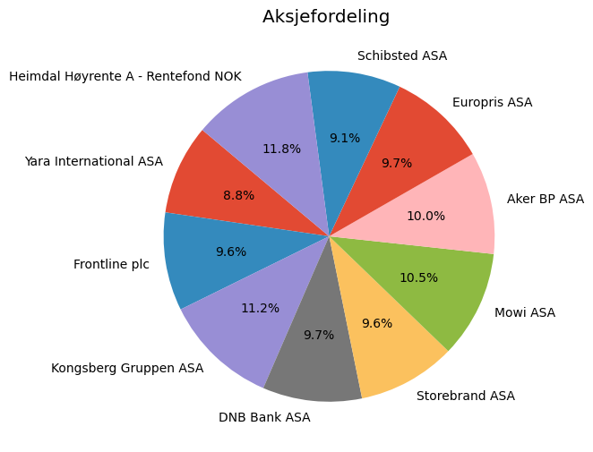

```python
stock_names = []
for ticker in tickers_t:
    stock_info = yf.Ticker(ticker)
    try:
        name = stock_info.info['longName']
        stock_names.append(name)
    except KeyError:
        stock_names.append("Unknown")

plt.figure(figsize=(10, 6))
plt.pie(holders, labels=stock_names, autopct='%1.1f%%', startangle=140)
plt.title('Aksjefordeling ')
plt.show()
```

## Sektor

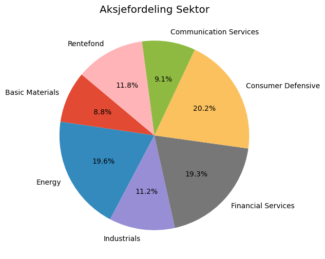

```python
sectors_dict = {}

for ticker, holder in zip(tickers_t, holders):
    stock_info = yf.Ticker(ticker)
    try:
        sector = stock_info.info['sector']
    except KeyError:
        sector = "Rentefond"

    if sector not in sectors_dict:
        sectors_dict[sector] = 0
    sectors_dict[sector] += holder


labels = list(sectors_dict.keys())
values = list(sectors_dict.values())


plt.figure(figsize=(10, 6))
plt.pie(values, labels=labels, autopct='%1.1f%%', startangle=140)
plt.title('Aksjefordeling Sektor')
plt.show()
```

# Risiko-analyse

## Boksplott

Boksplottet viser fordelingen av prosentendringer for hver aksje, og boksene representerer interkvartilavstanden (IQR) for prosentendringene. Dette gir en visuell representasjon av volatiliteten eller risikoen knyttet til hver aksje i porteføljen. Hentet fra: https://tradewithpython.com/portfolio-analysis-using-python

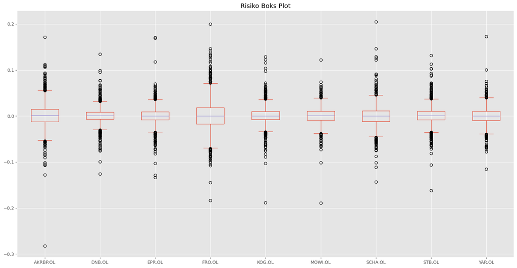

```python
returns.plot(kind = "box",figsize = (20,10), title = "Risiko Boks Plot")
```

# Sharpe Ratio

Sharpe-ratioen er en måling av avkastningen på en investering per enhet av risiko. Den beregnes ved å ta differansen mellom den forventede avkastningen på investeringen og risikofri rente, og deretter dele dette tallet på standardavviket av investeringens avkastning.

En høyere Sharpe-ratio indikerer bedre avkastning per enhet risiko og antyder en mer effektiv utnyttelse av investert kapital.

Hentet fra: #https://www.codearmo.com/blog/sharpe-sortino-and-calmar-ratios-python

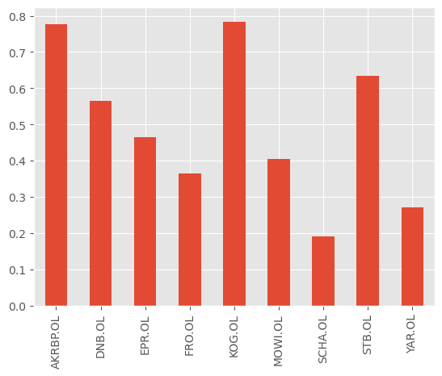

```python
def sharpe_ratio(return_series, N, rf):
    mean = (return_series.mean() * N) -rf
    sigma = return_series.std() * np.sqrt(N)
    return mean / sigma

N = 255
rf =0.02
sharpes = returns.apply(sharpe_ratio, args=(N,rf,),axis=0)

sharpes.plot.bar()
```

# Sortino Ratio

Sortino-ratioen er en justert versjon av Sharpe-ratioen som fokuserer på nedsidevolatilitet i stedet for total volatilitet. Den måler avkastningen per enhet av risiko, men risikoen er definert som volatiliteten av porteføljen negativ avkastning, kalt "downside deviation".

Sortino-ratioen gir dermed en mer differensiert innsikt ved å vurdere kun risikoen knyttet til uønskede, negative avkastninger

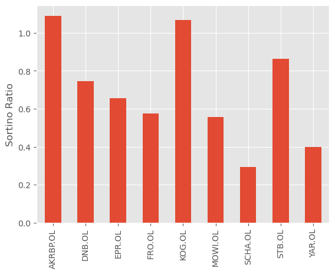

```python
def sortino_ratio(series, N,rf):
    mean = series.mean() * N -rf
    std_neg = series[series<0].std()*np.sqrt(N)
    return mean/std_neg


sortinos = returns.apply(sortino_ratio, args=(N,rf,), axis=0 )
sortinos.plot.bar()
plt.ylabel('Sortino Ratio')
```

## Max Drawdown

Max drawdown representerer den største prosentvise nedgangen i verdien av en investering fra en topp til en bunn i en gitt periode. Den måler dermed det største tapet en investor ville ha opplevd hvis de hadde kjøpt på et tidspunkt før nedgangen og solgt på bunnen.

Jo lavere max drawdown, desto mindre er tapet som oppstår under ugunstige markedsforhold. Det gir en indikasjon på det potensielle tapet en investor kan oppleve i en dårlig periode

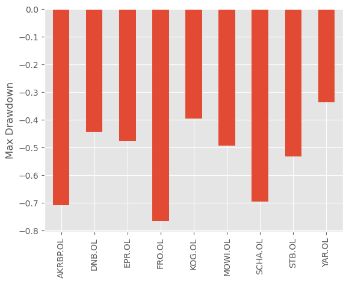

```python
def max_drawdown(return_series):
    comp_ret = (return_series+1).cumprod()
    peak = comp_ret.expanding(min_periods=1).max()
    dd = (comp_ret/peak)-1
    return dd.min()


max_drawdowns = returns.apply(max_drawdown,axis=0)
max_drawdowns.plot.bar()
plt.ylabel('Max Drawdown')
```

## Calmars

Calmar-ratioen måler forholdet mellom årlig avkastning og det maksimale drawdown (største tap) i en investeringsportefølje.

Calmar-ratioen gir innsikt i hvor mye avkastning som er generert i forhold til det største tapet i porteføljen. Høyere Calmar-ratio indikerer bedre risikojustert avkastning.

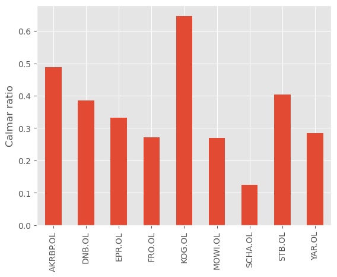

```python
calmars = returns.mean()*255/abs(max_drawdowns)

calmars.plot.bar()
plt.ylabel('Calmar ratio')
```

## Oppsummering Risiko

Tabell over de ulike aksjene og deres ulike risiko-rtioer.

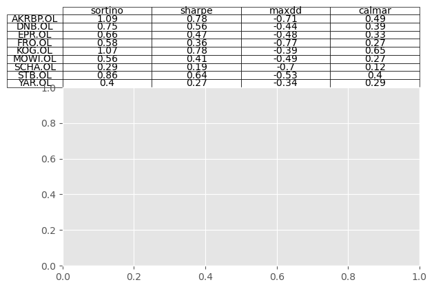

```python
tabell = pd.DataFrame()
tabell['sortino'] = sortinos
tabell['sharpe'] = sharpes
tabell['maxdd'] = max_drawdowns
tabell['calmar'] = calmars

plt.table(cellText=np.round(tabell.values,2), colLabels=tabell.columns,
          rowLabels=tabell.index,rowLoc='center',cellLoc='center',loc='top',
          colWidths=[0.25]*len(tabell.columns))
plt.tight_layout()
```

# Korrelasjon

Viser korrelasjonenen mellom aksjene i porteføljen. Hentet fra: https://tradewithpython.com/portfolio-analysis-using-python

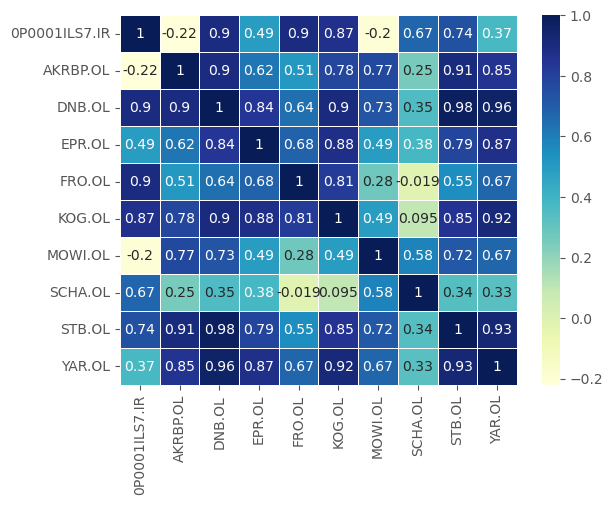

```python
import seaborn as sb
correlation_matrix = data.corr(method='pearson')
fig1 = plt.figure()
sb.heatmap(correlation_matrix,xticklabels=correlation_matrix.columns, yticklabels=correlation_matrix.columns,
cmap='YlGnBu', annot=True, linewidth=0.5)
plt.show(fig1)
```

## Voltilitet

Viser daglig volaitilitet av hver enkelt aksje samlet. Kilde: https://tradewithpython.com/portfolio-analysis-using-python

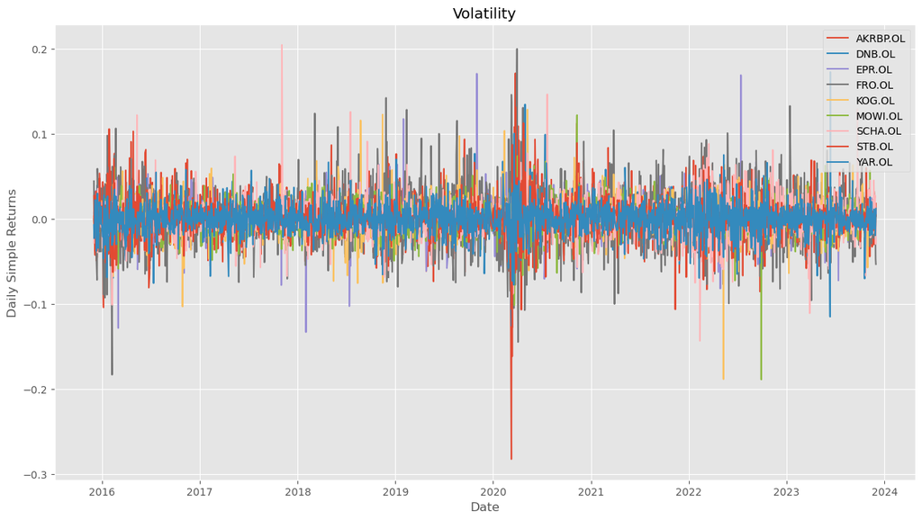

```python
plt.figure(figsize=(15, 8))

for i in returns.columns.values:
    plt.plot(returns.index, returns[i], label=i)

plt.legend(loc='upper right')
plt.title('Volatility')
plt.xlabel('Date')
plt.ylabel('Daily Simple Returns')

plt.show()
```

# Portefølje Optimalisering

```python
data_stock = yf.download(tickers_s, start_t, end_t)['Adj Close'].ffill()
data_stock.dropna()
returns_stock = data_stock.pct_change()
```

```
[*********************100%%**********************]  9 of 9 completed
```

## Nøkkeltall

Nøkkelatall analyse. Ble litt mye hard-koding, men her plotter jeg de viktigste nøkkeltallene. Tallene skal være de seneste nøkkeltallene hentet fra Yahoo Finance. Hentet de herifra siden det er eneste siden jeg har funnet som er gratis å hente ut data fra. Tallene er dog ikke alltid riktig, så da blir det alikevell litt problematisk å bruke. Går likevell an å jobbe med tallene og lage fundamentale algoritmer rundt de for øvings skyld.

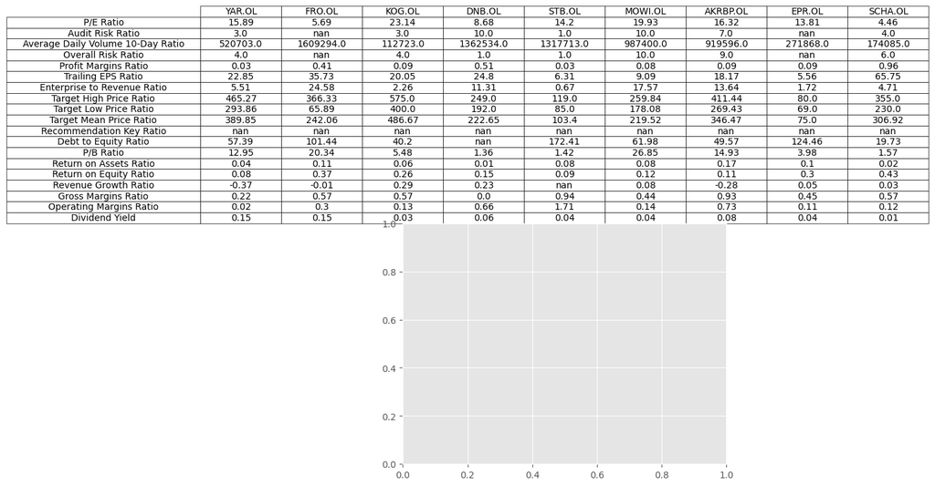

```python
tickers = tickers_s

pe_ratios = []
auditRisk_ratios = []
ad_ratios = []
o_risk_ratios = []
pm_ratios = []
eps_ratios = []
etr_ratios = []
thp_ratios = []
tlp_ratios = []
tmp_ratios = []
rk_ratios = []
dte_ratios = []
pb_ratios = []
roa_ratios = []
roe_ratios = []
rg_ratios = []
rm_ratios = []
om_ratios = []
dividend_yields = []


for ticker in tickers:
    stock_info = yf.Ticker(ticker)

    try:
        pe_ratio = stock_info.info['trailingPE']
    except KeyError:
        pe_ratio = np.nan
    pe_ratios.append(pe_ratio)

    try:
        auditRisk_ratio = stock_info.info['auditRisk']
    except KeyError:
        auditRisk_ratio = np.nan
    auditRisk_ratios.append(auditRisk_ratio)

    try:
        ad_ratio = stock_info.info['averageDailyVolume10Day']
    except KeyError:
        ad_ratio = np.nan
    ad_ratios.append(ad_ratio)

    try:
        o_risk_ratio = stock_info.info['overallRisk']
    except KeyError:
        o_risk_ratio = np.nan
    o_risk_ratios.append(o_risk_ratio)

    try:
        pm_ratio = stock_info.info['profitMargins']
    except KeyError:
        pm_ratio = np.nan
    pm_ratios.append(pm_ratio)

    try:
        eps_ratio = stock_info.info['trailingEps']
    except KeyError:
        eps_ratio = np.nan
    eps_ratios.append(eps_ratio)

    try:
        etr_ratio = stock_info.info['enterpriseToRevenue']
    except KeyError:
        etr_ratio = np.nan
    etr_ratios.append(etr_ratio)

    try:
        thp_ratio = stock_info.info['targetHighPrice']
    except KeyError:
        thp_ratio = np.nan
    thp_ratios.append(thp_ratio)

    try:
        tlp_ratio = stock_info.info['targetLowPrice']
    except KeyError:
        tlp_ratio = np.nan
    tlp_ratios.append(tlp_ratio)

    try:
        tmp_ratio = stock_info.info['targetMeanPrice']
    except KeyError:
        tmp_ratio = np.nan
    tmp_ratios.append(tmp_ratio)

    try:
        rk_ratio = stock_info.info['recommendationKey']
    except KeyError:
        rk_ratio = np.nan
    rk_ratios.append(rk_ratio)

    try:
        dte_ratio = stock_info.info['debtToEquity']
    except KeyError:
        dte_ratio = np.nan
    dte_ratios.append(dte_ratio)

    try:
        pb_ratio = stock_info.info['priceToBook']
    except KeyError:
        pb_ratio = np.nan
    pb_ratios.append(pb_ratio)

    try:
        roa_ratio = stock_info.info['returnOnAssets']
    except KeyError:
        roa_ratio = np.nan
    roa_ratios.append(roa_ratio)

    try:
        roe_ratio = stock_info.info['returnOnEquity']
    except KeyError:
        roe_ratio = np.nan
    roe_ratios.append(roe_ratio)

    try:
        rg_ratio = stock_info.info['revenueGrowth']
    except KeyError:
        rg_ratio = np.nan
    rg_ratios.append(rg_ratio)

    try:
        rm_ratio = stock_info.info['grossMargins']
    except KeyError:
        rm_ratio = np.nan
    rm_ratios.append(rm_ratio)

    try:
        om_ratio = stock_info.info['operatingMargins']
    except KeyError:
        om_ratio = np.nan
    om_ratios.append(om_ratio)

    try:
        dividend_yield = stock_info.info['dividendYield']
    except KeyError:
        dividend_yield = np.nan
    dividend_yields.append(dividend_yield)



fundamental_tabell = pd.DataFrame()
fundamental_tabell['P/E Ratio'] = pe_ratios
fundamental_tabell['Audit Risk Ratio'] = auditRisk_ratios
fundamental_tabell['Average Daily Volume 10-Day Ratio'] = ad_ratios
fundamental_tabell['Overall Risk Ratio'] = o_risk_ratios
fundamental_tabell['Profit Margins Ratio'] = pm_ratios
fundamental_tabell['Trailing EPS Ratio'] = eps_ratios
fundamental_tabell['Enterprise to Revenue Ratio'] = etr_ratios
fundamental_tabell['Target High Price Ratio'] = thp_ratios
fundamental_tabell['Target Low Price Ratio'] = tlp_ratios
fundamental_tabell['Target Mean Price Ratio'] = tmp_ratios
fundamental_tabell['Recommendation Key Ratio'] = rk_ratios
fundamental_tabell['Debt to Equity Ratio'] = dte_ratios
fundamental_tabell['P/B Ratio'] = pb_ratios
fundamental_tabell['Return on Assets Ratio'] = roa_ratios
fundamental_tabell['Return on Equity Ratio'] = roe_ratios
fundamental_tabell['Revenue Growth Ratio'] = rg_ratios
fundamental_tabell['Gross Margins Ratio'] = rm_ratios
fundamental_tabell['Operating Margins Ratio'] = om_ratios
fundamental_tabell['Dividend Yield'] = dividend_yields


fundamental_tabell = fundamental_tabell.apply(pd.to_numeric, errors='coerce')
fundamental_tabell = fundamental_tabell.round(2)


fundamental_tabell = fundamental_tabell.T

plt.table(cellText=fundamental_tabell.values, rowLabels=fundamental_tabell.index,
          colLabels=tickers, rowLoc='center', cellLoc='center', loc='top',
          colWidths=[0.25] * len(tickers))
plt.show()
```

## Porteføljeoptimalisering fra et biblotek

Denne koden bruker PyPortfolioOpt-biblioteket for porteføljeforvaltning i Python for å optimalisere en portefølje basert på historisk avkastning og risiko for en gitt samling av aksjer. Gir oss da en gitt portefølje av de aksjene vi har med ulike vektlegging. Dette gir en fin måte å bli kjent med eksisterende bibloteker og hvordan man bruker de

Biblotek: https://github.com/robertmartin8/PyPortfolioOpt/tree/master

```python
import pandas as pd
from pypfopt import EfficientFrontier
from pypfopt import risk_models
from pypfopt import expected_returns


df = data_stock

mu = expected_returns.mean_historical_return(df)
S = risk_models.sample_cov(df)


ef = EfficientFrontier(mu, S)
raw_weights = ef.max_sharpe()
cleaned_weights = ef.clean_weights()
ef.save_weights_to_file("weights.csv")



print("Optimal Portefølje Allokasjon:")
print(pd.Series(cleaned_weights))
print()


print("\nPorttefølje Prestasjon:")
ef.portfolio_performance(verbose=True)
```

```
Optimal Portefølje Allokasjon:
AKRBP.OL    0.22153
DNB.OL      0.00496
EPR.OL      0.11257
FRO.OL      0.00000
KOG.OL      0.42449
MOWI.OL     0.05738
SCHA.OL     0.00000
STB.OL      0.17906
YAR.OL      0.00000
dtype: float64


Porttefølje Prestasjon:
Expected annual return: 21.4%
Annual volatility: 21.9%
Sharpe Ratio: 0.88
```

```
(0.21384865435779948, 0.21939150117515244, 0.883574128074539)
```